# depth_native functions

# Totally different approach

Previously I quantified the distribution of the **count** of suprathreshold voxels for each depth bin.

This is however likely *not* the best option since the count does not reflect the magnitude of the parameter estimate for a given contrast.

The best would be to use the COPEs directly, but in this case there would be huge problems with the variability across runs.

In this notebook, I determine for each cortical bin the mean (and sderr) of the thresholded zstat for all the voxels in that cortical depth. Then I will use these estimates in a group-level analysis for each depth bin in each ROI across participants.

The choice of using the thresholded zstat instead of the raw zstat is twofold: - first the thresholded zstat are already present only on the map of cortical depth, which is where I want to estimate my statistic - second, the thresholded zstat have already been corrected for MCP

Of course I will also here have the problem that in some sub/ROIs there will be no voxels > Zthr.

## Select sub, Zthr and Zcontrast

```r
# All of the following will become selector widgets

SUBID = "sub_02"     # df %>% distinct(sub) to see all available sub
Zcontrast <- "thresh_zstat2"
Zthr <- 3.1
clusterSizeThr <- 100  # to build a meaningful histogram
nbin <- 20 # set hist breaks to a fixed range

# -----------------------------------------------------------------------------

# Immutable parameters
gitdir <- "/data00/layerfMRI/Github_repo/"
bd <- paste0(gitdir,"layerfMRI/analyses/depth_native/")

library(stringr)
library(tidyr)
library(dplyr)
library(purrr)
select <- dplyr::select
library(ggplot2)
library(ggthemes)
library(tictoc)


julabels <- read.csv("labels_juelich.csv") %>%
  mutate(name = str_replace(name,"['-/]","")) %>%    # get rid of special chars
  mutate(numba = index + 1) %>%
  select(-index)
```

## Create dictionary of data from `list.files`

The magic is provided by `tidyr::separate`

```r
create_dizio_files <- function(data_native_dir = "data_native") {

  df <- list.files("data_native", recursive = T) %>% as.data.frame()
  names(df) <- "fname"


  df <- df %>%
    rowwise() %>%
    tidyr::separate(
      fname, c("sub","contrast","taskrun","zstat"),
      sep = "/", fill = "right", remove = FALSE
    ) %>%
    mutate(taskrun = str_extract(taskrun,"task_[1-4]\\_run_[1-2]")) %>%
    mutate(zstat = str_extract(zstat,"thresh_zstat[1-4]")) %>%
    mutate(pathname = paste0(bd,"/data_native/",fname)) %>%
    dplyr::select(-fname)

  return(df)
}



# ------------------------------  Code for Main -------------------------------
# df <- create_dizio_files()



df <- create_dizio_files()
# show df tree
library(collapsibleTree)
dataset <- df %>% dplyr::select(sub,contrast,taskrun,zstat)
collapsibleTree(dataset, c("sub","contrast","taskrun","zstat"), collapsed = T, zoomable = F)
```

[interactive chart not shown]

## Load Z, D, JU and extract values for Z sig voxels

Load the nii for Zmaps (thresh_Zstat[1..4]), Depth and JUelich atlases, all in native space:

- Z_nii : 8 for each contrast (Motion, Scrambled, M>S, S>M)
- D_nii : 8, one for each taskrun
- JU_nii : 8, one for each taskrun

Then for each run/contrast 1. threshold the Z_nii to Z_thr and create a Zthr_idx of suprathreshold voxels 2. extract Z_vals, D_vals and JU_vals at the locations of Zthr_idx 3. purrr Z, D, JU vals into a list of tibbles (8) 4. retain for each taskrun/tibble only the Z and D vals where JU > 0 - i.e. inside JU ROIs

**NB**: the two functions are separate so that I don’t need to reload the niis if I choose another Z threshold

```r
library(RNifti)

load_niis <- function(SUBID, Zcontrast) {

  # Load the Z_nii for a given contrast (8, one for each taskrun)
  Z_nii <- df %>%
    filter(sub == SUBID, contrast == "Zstat", zstat == Zcontrast) %>%
    select(pathname) %>% sapply(readNifti)

  # Load the D_nii (8 taskrun)
  D_nii <- df %>%
    filter(sub == SUBID, contrast == "depth") %>%
    select(pathname) %>% sapply(readNifti)

  # Load the JU_nii (8 taskrun)
  JU_nii <- df %>%
    filter(sub == SUBID, contrast == "atlas") %>%
    select(pathname) %>% sapply(readNifti)

  niis <- list(Z = Z_nii, D = D_nii, JU = JU_nii)

  return(niis)
}


get_Z_D_JU_vals <- function(Z_thr, Z_nii, D_nii, JU_nii) {

  # Create an index of sig voxels according to Zthr
  Zthr_idx <- sapply(Z_nii, function(x) {which(x > Zthr)})

  # Extract Z, D, JU values at the location of Zthr_idx
  Z_vals <- mapply( function(vols,idx) vols[idx], Z_nii, Zthr_idx )
  D_vals <- mapply( function(depth,idx) depth[idx], D_nii, Zthr_idx )
  JU_vals <- mapply( function(atlas,idx) atlas[idx], JU_nii, Zthr_idx )

  # Purrr everything into a list of tibbles and retain only D,Z values
  # inside JU ROIs
  vals <- pmap(
    list(Z_vals, D_vals, JU_vals),
    function(Z,D,JU) tibble(Z,D,JU) %>% filter(JU > 0)
  )


  return(vals)
}


# ------------------------------  Code for Main -------------------------------

niis <- load_niis(SUBID, Zcontrast)

vals <- get_Z_D_JU_vals(Z_thr, niis$Z, niis$D, niis$JU)
```

# Get mean Z for each D bin in each JU region

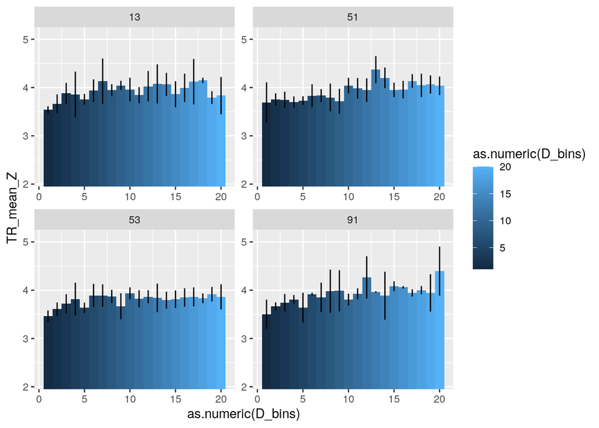

```r
# # Set at the beginning
# clusterSizeThr <- 100
# nbin <- 10

# # Development for one taskrun
#
# v <- vals[[1]]
#
#
# vZD <- v %>%
#   group_by(JU) %>%
#   mutate(nvox = n()) %>%              # count numba vox in each JU ROI
#   arrange(nvox, JU) %>%               # arrange nvox by nvox,JU to check
#   filter(nvox > clusterSizeThr) %>%   # remove JU with nvox < clusterSizeThr
#   group_split() %>%
#   map(~ .x %>% mutate(D_bins = ntile(D, nbin) %>% as.factor) %>% arrange(D) ) %>%
#   map(~ .x %>% group_by(D_bins) ) %>%
#   map(~ .x %>% summarise(
#     mean_Z = mean(Z),
#     sd_Z = sd(Z),
#     JU = mean(JU),
#     .groups = "drop"
#   )) %>%
#   bind_rows()
#
#
#
# vZD %>%
#   ggplot( aes(x = as.numeric(D_bins), y = mean_Z, fill = as.numeric(D_bins)) ) +
#   geom_bar(stat = "identity", width = 1) +
#   coord_cartesian(ylim = c(1.9, Zthr + 2)) +
#   facet_wrap(~ JU, scales = "free")




get_meanZ <- function(df_vals_taskrun) {

  meanZ <- df_vals_taskrun %>%
  group_by(JU) %>%
  mutate(nvox = n()) %>%              # count numba vox in each JU ROI
  arrange(nvox, JU) %>%               # arrange nvox by nvox,JU to check
  filter(nvox > clusterSizeThr) %>%   # remove JU with nvox < clusterSizeThr
  group_split() %>%
  map(~ .x %>% mutate(D_bins = ntile(D, nbin) %>% as.factor) %>% arrange(D) ) %>%
  map(~ .x %>% group_by(D_bins) ) %>%
  map(~ .x %>% summarise(
    mean_Z = mean(Z),
    # sd_Z = sd(Z),
    JU = mean(JU),
    .groups = "drop"
  )) %>%
  bind_rows()

  return(meanZ)
}

# madonna!
many_meanZ <- map(vals, get_meanZ)

# assign a taskrun column - for further averaging - and bind_rows all together
allmeanZ <- pmap(
  list(1:length(many_meanZ), many_meanZ),
  function(numba, df_taskrun) df_taskrun %>% mutate(taskrun = numba)
) %>% bind_rows()


# get the mean Z across taskrun
# IMPORTANT: HERE YOU NEED TO IMPLEMENT THE THRESHOLD FOR NUMBA OF SIG TASKRUNS
all_TR_meanZ <- allmeanZ %>%
  group_by(JU) %>%
  group_split() %>%
  map(~ .x %>% group_by(D_bins) ) %>%
  map(~ .x %>% summarise(
    TR_mean_Z = mean(mean_Z),
    sd_Z = sd(mean_Z),
    JU = mean(JU),
    .groups = "drop"
  )) %>% bind_rows() %>%
  filter(!is.na(sd_Z))


all_TR_meanZ %>%
  ggplot( aes(x = as.numeric(D_bins), y = TR_mean_Z, fill = as.numeric(D_bins)) ) +
  geom_bar(stat = "identity", width = 1) +
  geom_linerange( aes(ymin = TR_mean_Z - sd_Z, ymax = TR_mean_Z + sd_Z) ) +
  coord_cartesian(ylim = c(Zthr - 1, Zthr + 2)) +
  facet_wrap(~ JU, scales = "free")
```